# roadmap

# Roadmap

Welcome to our roadmap. Here, you’ll find our plan for the next few major updates, so you know what you’ll get with your purchase and when to expect more content.

The headings below indicate when we *expect* to complete a major milestone. However:

- We may release earlier. We typically release content updates as soon as new content is ready.
- We’ll also release minor updates often. We have many planned improvements we intend to add as we go. We also typically make bugfix releases as fast as possible when we find or learn about bugs and typos.

The roadmap focuses on planned new content. To learn more about the updates we made, you’ll want to look at the changelog. There, you can see exactly when we released an update and what came with it: new content, improvements, changes, and fixes.

Note that once you own Godot Node Essentials, updates come at no extra cost. Also, we’ll increase the product’s price with updates.

## Milestone 1: general and 2D nodes

*Released on 2021/07/16*

[figure not shown]

That’s the first early-access release of Godot Node Essentials, which is already out.

It brings 13 node guides about some of the most common nodes to make games in Godot. While it focuses on 2D, you’ll use nodes like `Timer`, `Viewport`, and more in 3D.

## Milestone 2: UI nodes

*Released on 2021/08/09*

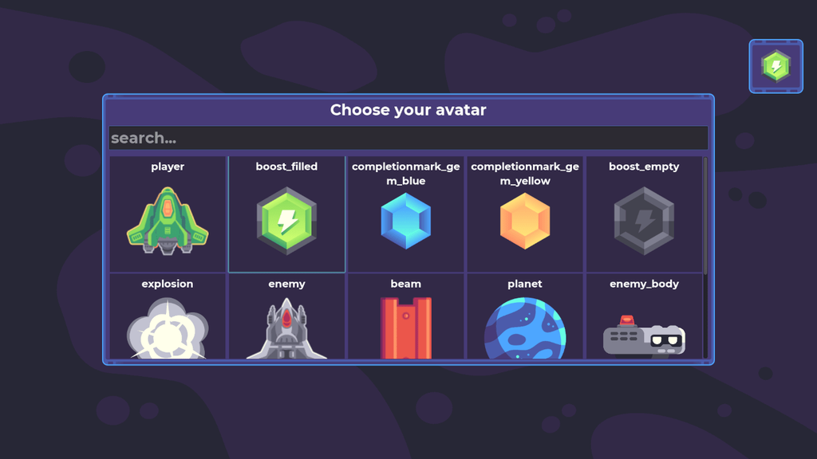

We’re focusing on crucial UI nodes for the next major release, the ones you’re most likely to use in your projects. We’ll also add an extensive guide about audio in this update.

After that, we’ll work on 3D. We’re focusing on UI before 3D as you’ll use those nodes in both 2D and 3D games.

The update will cover the following ten nodes:

- HBoxContainer and VBoxContainer, a staple to arrange your UI widgets in rows or columns.
- ProgressBar and TextureProgress for all your bars and gauges.
- Button and OptionButton. You can use them for about anything you want the player to click in your UI, from menu options to items in an inventory.
- PanelContainer, a handy node to automatically fit your UI in a panel or resize the background panel to fit the UI’s content.
- LineEdit lets the player type names, logins, passwords and gives you utilities to validate their queries.
- NinePatchRect, to draw textures that smartly tile borders and scale with any surface.
- AudioStreamPlayer, derived nodes and audio effects, for all your audio needs.

The price increased to **$80** with this update.

## Milestone 3: 3D nodes

Estimated release date: November 15, 2021

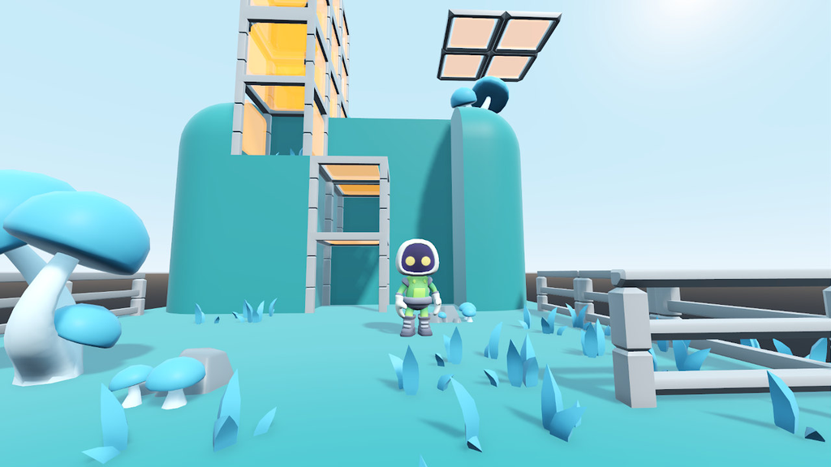

Our third milestone will focus on 3D.

We’ll write the complete list of nodes we’ll cover at a later date, but you can expect at least ten new guides, including:

- Area, KinematicBody, and RigidBody
- Cameras
- Lights
- RayCast
- And displaying meshes

The price will increase to **$100** with this update.

This release will mark the end of early access.

## Future releases

### After the Godot 4.0 release

Estimated release date: to be announced after Godot 4 comes out.

We will update node essentials for Godot 4. We’ll adapt the code to the new version of GDScript, update the pictures, and everything that changes in this new major version of the engine.

We also want to take advantage of the new language and node features to improve the guides and give you the best of Godot 4.

If you own Godot Node Essentials or our Ultimate Godot course bundle already, the update will come free of charge.

### Covering more nodes and guides

We’re looking to cover more nodes if possible.

However, please note that it depends entirely on the course’s sales as all our budget comes from there. GDQuest is an entirely self-funded small team working with limited resources.

With your purchase, you will get *at least* all the above.

Then, if we can sell 500 copies by the end of 2021, this will give us enough budget to keep going, and we’ll keep covering more nodes.